# El hierro

## El inicio del viaje

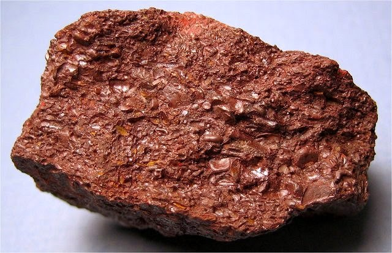

Mineral de hierro - Fuente: es.geologyscience.com

El hierro es uno de los metales más antiguos y útiles que conoce la humanidad. Está en los puentes, en las herramientas del taller y en las máquinas que mueven la industria. Pero para que llegue a nuestras manos como un material resistente y moldeable, debe pasar por un proceso fascinante que comienza en la tierra misma.

Todo empieza con el **mineral de hierro**, una roca que contiene compuestos de hierro mezclados con oxígeno e impurezas. Sin embargo, en ese estado no puede usarse; necesita ser transformado en un metal utilizable.

## El coque: un combustible especial

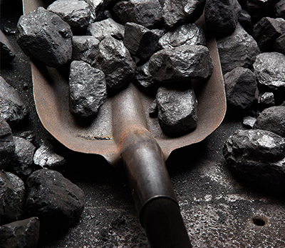

Coque - Fuente: repsol.es

Para transformar el mineral, se necesita mucho calor, y un combustible capaz de alcanzarlo: el **coque**. Pero el coque no es carbón común. Se obtiene al calentar carbón mineral en hornos cerrados, sin oxígeno. Este proceso deja un material poroso, duro y que arde con gran intensidad.

En la obtención del hierro, el coque cumple dos funciones vitales:

1. Genera el calor necesario para fundir el mineral.
2. Produce un gas reductor (monóxido de carbono) que ayuda a separar el oxígeno del hierro.

## El gigante que transforma: el alto horno

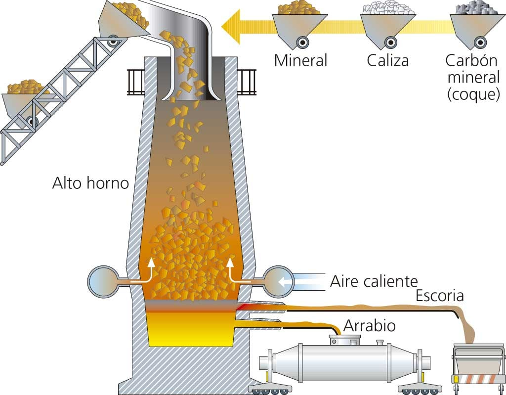

Alto horno - Fuente: blog.laminasyaceros.com

El **alto horno** es una enorme torre de acero revestida por dentro con materiales refractarios que soportan temperaturas de más de **1.500 °C**. Por la parte superior se cargan capas alternadas de mineral de hierro, coque y caliza (fundente). Por la parte inferior, se inyecta aire caliente para mantener la combustión.

La caliza, como fundente, ayuda a eliminar impurezas del hierro líquido.

Dentro del horno, ocurren las reacciones químicas de reducción y fusión. El hierro liberado se va acumulando en estado líquido en la parte inferior del horno.

## Nace el arrabio

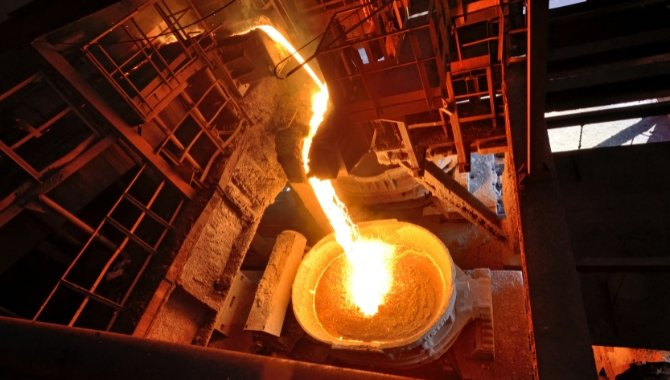

El arrabio saliendo de un alto horno - Fuente: eastcarb.com

El producto que se obtiene es el **arrabio**, una mezcla líquida de hierro y carbono (2 a 5 %) con otras impurezas. No es todavía el hierro que conocemos para fabricar herramientas; es demasiado frágil para muchas aplicaciones. Pero es el punto de partida para llegar a materiales más útiles.

Junto al arrabio se forma la **escoria**, una mezcla de impurezas y fundentes fundidos, que flota sobre el hierro líquido y se retira por separado.

## Del arrabio al hierro y al acero

El **arrabio** sale del alto horno **líquido y muy caliente**, separado de la escoria. Se transporta por **canales o cucharas especiales** hasta el **horno de afinado**. Allí se **reduce el carbono** y se eliminan impurezas.

- Poco carbono → **hierro puro**, blando y maleable.
- Carbono moderado → **acero**, más fuerte y resistente.

Este proceso transforma el arrabio en un metal **apto para herramientas, máquinas y estructuras**.

## Resumen del viaje

El hierro que encontramos en las herramientas no nació así. Pasó de ser mineral en la tierra, a fundirse en el alto horno, a transformarse en arrabio y luego en hierro o acero listo para ser trabajado.